# Bumblebee Flapping Kinematics Revision 1

Callin Switzer

July 25, 2019

### Updates from first submission

1. Remove all delta variable ^2’s
2. Re-named variables to make them easier to read
3. Removed analysis that used arclen

### Avenues of analysis:

1. Confirm expectation that Metabolic rate and a proxy for translational force production increased with total mass supported during flight.
2. we see how $\Delta$load affects $\Delta$amplitude and $\Delta$frequency, accounting for bee size and treatment order
3. We check to see how $\Delta$frequency and $\Delta$amplitude are associated with $\Delta$MetabolicRate, while accounting for $\Delta$load

### Measured variables:

- BeeID: Name given to an invididual (subscript in equations) (renamed as, “bee_ID” in analysis)
- order: This is the trial number per individual, either 1 or 2
- Treatment: Either light or heavy. H is with both nectar and external load, L is just nectar load (subscript in equations) (Note: changed to “treatment” in analysis)
- Mstarved: The empty mass of the bee after being starved for days, until it no longer buzzes when prodded in grams (changed in analysis to mass_starved)
- M2: Total mass of the bee and load at beginning of trial in grams (changed to mass_0)
- MF: The mass of the bee and load at end of trial in grams (changed in analysis to mass_f)
- ITSpan = intertegular span in m
- S = area of both forewings in $m^2$
- metabolic_rate = Metabolic rate in mL $CO_2$ $hr^{-1}$
- freq = wing beat frequency in Hz
- amp = stroke amplitude of forewing in degrees
- wingLen = length of forewing from wing base to tip in meters (changed in analysis to wing_len)

## load packages and change global settings

```r
# install packages
ipak <- function(pkg){
  new.pkg <- pkg[!(pkg %in% installed.packages()[, "Package"])]
  if(length(new.pkg)) install.packages(new.pkg, dependencies = TRUE)
  sapply(pkg, require, character.only = TRUE)
}

packages <- c("roll", "lme4", "lmerTest", "influence.ME", "data.table", "tidyverse")
ipak(packages)
```

```
##         roll         lme4     lmerTest influence.ME   data.table
##         TRUE         TRUE         TRUE         TRUE         TRUE
##    tidyverse
##         TRUE
```

```r
# set ggplot theme
theme_set(theme_classic() +
            theme(axis.text=element_text(colour="black"),
                  text=element_text(size=10)))

# set  directories
dataDir <- file.path(getwd(), "data")
figDir <- file.path(getwd(), "figures")
dataOut <- file.path(getwd(), "dataOutput")

print(paste("last run ", Sys.time()))
```

```
## [1] "last run  2019-08-19 15:18:32"
```

```r
print(R.version)
```

```
##                _
## platform       x86_64-w64-mingw32
## arch           x86_64
## os             mingw32
## system         x86_64, mingw32
## status
## major          3
## minor          5.3
## year           2019
## month          03
## day            11
## svn rev        76217
## language       R
## version.string R version 3.5.3 (2019-03-11)
## nickname       Great Truth
```

### Import data

```r
raw_data <- read_csv(file.path(dataDir, "beeRespData_freqUpdated.csv"))
summary(raw_data)
```

```
##     BeeID               order      Treatment            Mstarved
##  Length:60          Min.   :1.0   Length:60          Min.   :0.0767
##  Class :character   1st Qu.:1.0   Class :character   1st Qu.:0.1213
##  Mode  :character   Median :1.5   Mode  :character   Median :0.1378
##                     Mean   :1.5                      Mean   :0.1411
##                     3rd Qu.:2.0                      3rd Qu.:0.1670
##                     Max.   :2.0                      Max.   :0.1909
##        M2               MF             Itspan               S
##  Min.   :0.1062   Min.   :0.0969   Min.   :0.003860   Min.   :4.010e-05
##  1st Qu.:0.1808   1st Qu.:0.1762   1st Qu.:0.004400   1st Qu.:5.590e-05
##  Median :0.2191   Median :0.2107   Median :0.004620   Median :6.130e-05
##  Mean   :0.2245   Mean   :0.2154   Mean   :0.004594   Mean   :6.141e-05
##  3rd Qu.:0.2646   3rd Qu.:0.2576   3rd Qu.:0.004870   3rd Qu.:6.750e-05
##  Max.   :0.3550   Max.   :0.3440   Max.   :0.005180   Max.   :7.810e-05
##       MetR             amp            wingLen               MT
##  Min.   : 5.507   Min.   : 96.88   Min.   :0.008691   Min.   :0.1016
##  1st Qu.: 8.935   1st Qu.:114.16   1st Qu.:0.010570   1st Qu.:0.1779
##  Median :10.666   Median :125.96   Median :0.011017   Median :0.2153
##  Mean   :10.600   Mean   :123.31   Mean   :0.010911   Mean   :0.2199
##  3rd Qu.:12.297   3rd Qu.:133.61   3rd Qu.:0.011444   3rd Qu.:0.2612
##  Max.   :16.475   Max.   :144.78   Max.   :0.012118   Max.   :0.3495
##       load            perLoad         freq_audio      freq_video
##  Min.   :0.01310   Min.   : 13.00   Min.   :157.6   Min.   :154.3
##  1st Qu.:0.04371   1st Qu.: 28.41   1st Qu.:174.3   1st Qu.:170.9
##  Median :0.07375   Median : 55.54   Median :178.4   Median :177.1
##  Mean   :0.07878   Mean   : 56.66   Mean   :180.0   Mean   :176.9
##  3rd Qu.:0.11565   3rd Qu.: 82.45   3rd Qu.:187.5   3rd Qu.:184.0
##  Max.   :0.16085   Max.   :109.06   Max.   :198.9   Max.   :204.5
```

# Data tidying

```r
# new frequency data
bdta <- raw_data %>%
  # rename variables
  rename(
         metabolic_rate = MetR,
         mass_starved = Mstarved,
         wing_len = wingLen,
         mass_0 = M2,
         mass_f = MF,
         IT_span = Itspan,
         treatment = Treatment,
         bee_ID  = BeeID,
         freq = freq_audio # updated frequency data
         ) %>%
  # calculate new variables
  mutate(
     avg_mass = (mass_0 + mass_f)/2,
     load = avg_mass - mass_starved,
     perc_load = load / mass_starved * 100,
     arc_len = (0.75 *wing_len) * (amp * (pi / 180)),
     wing_velocity = arc_len * freq * 2,
     force = wing_velocity^2 * S,
     mass_spec_metabolic_rate = metabolic_rate / mass_starved,
     IT_span_mm = IT_span * 1000,

     # convert to factor variables
     order = as.factor(as.character(order)),
     treatment = as.factor(as.character(treatment)),
     bee_ID = as.factor(as.character(bee_ID))
     )



# Create a new dataframe that calculates the changes for each individual bee
newDF <- data.frame()
colsTocalc = c("order", "mass_0", "mass_f", "metabolic_rate",
               "freq", "amp", "load", "avg_mass",
               "perc_load", "force", "wing_velocity", "arc_len")

for(varb in colsTocalc){
     data_wide <- data.table::dcast(bdta,
                                    bee_ID + mass_starved + S +
                                      IT_span + wing_len ~
                             treatment, value.var=c(varb))
     colnames(data_wide)[6:7] = paste(varb,
                                      colnames(data_wide)[6:7], sep = "_")
     if(varb == colsTocalc[1]){
       newDF <- data_wide
     }
     else newDF <- merge(newDF, data_wide, all.y = TRUE)    %>% as.tbl()
}

head(newDF)
```

```
## # A tibble: 6 x 29
##   bee_ID mass_starved       S IT_span wing_len order_H order_L mass_0_H
##   <fct>         <dbl>   <dbl>   <dbl>    <dbl> <chr>   <chr>      <dbl>
## 1 E01           0.158 6.46e-5 0.00464  0.0112  2       1          0.263
## 2 E03           0.173 6.92e-5 0.00487  0.0114  1       2          0.311
## 3 E05           0.176 7.06e-5 0.00497  0.0117  2       1          0.278
## 4 E09           0.114 4.88e-5 0.0044   0.00987 1       2          0.228
## 5 E10           0.127 5.91e-5 0.00462  0.0106  1       2          0.217
## 6 E11           0.135 5.88e-5 0.00464  0.0107  1       2          0.222
## # ... with 21 more variables: mass_0_L <dbl>, mass_f_H <dbl>,
## #   mass_f_L <dbl>, metabolic_rate_H <dbl>, metabolic_rate_L <dbl>,
## #   freq_H <dbl>, freq_L <dbl>, amp_H <dbl>, amp_L <dbl>, load_H <dbl>,
## #   load_L <dbl>, avg_mass_H <dbl>, avg_mass_L <dbl>, perc_load_H <dbl>,
## #   perc_load_L <dbl>, force_H <dbl>, force_L <dbl>,
## #   wing_velocity_H <dbl>, wing_velocity_L <dbl>, arc_len_H <dbl>,
## #   arc_len_L <dbl>
```

```r
# Calculate $\Delta$ variables
newDF <- newDF %>%
  mutate(
     delta_perc_load = perc_load_H - perc_load_L,
     avg_perc_load = (perc_load_H + perc_load_L) / 2,
     delta_metabolic_rate = metabolic_rate_H - metabolic_rate_L,
     delta_arc_len = arc_len_H - arc_len_L,

     # center delta load
     delta_load_centered = scale(load_H - load_L,
                       center = TRUE, scale = FALSE),
     delta_load_not_centered = load_H - load_L,
     delta_load_centered2 = delta_load_centered^2,
     delta_amp = amp_H - amp_L,
     delta_freq = freq_H - freq_L,

     IT_span_mm = IT_span*1000,

     # reformat order so that it is more interpretable
     order_1 = recode(.$order_H,
                      "2" = "loadedSecond",
                      "1" = "loadedFirst")

    )
```

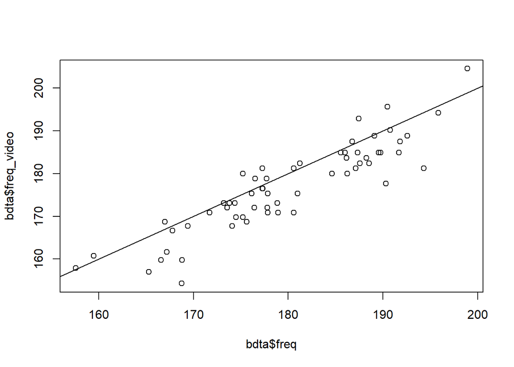

```r
# corr for audio vs. video frequency data
plot(bdta$freq, bdta$freq_video)
abline(0,1)
```

```r
cor(bdta$freq, bdta$freq_video)
```

```
## [1] 0.9022379
```

# Modeling & Figure generation

## Metabolic Rate vs. loading conditions

## Fig 3a

```r
# calculate mean and SD
tapply(bdta$metabolic_rate, INDEX = bdta$treatment,
       function(x) return(c(mean(x), sd(x))))
```

```
## $H
## [1] 11.722018  2.459945
##
## $L
## [1] 9.477230 2.393486
```

```r
m1 <- lmer(metabolic_rate ~ treatment * I(scale(avg_mass)) +
             (1|bee_ID), data = bdta)
summary(m1)
```

```
## Linear mixed model fit by REML. t-tests use Satterthwaite's method [
## lmerModLmerTest]
## Formula: metabolic_rate ~ treatment * I(scale(avg_mass)) + (1 | bee_ID)
##    Data: bdta
##
## REML criterion at convergence: 186.6
##
## Scaled residuals:
##     Min      1Q  Median      3Q     Max
## -1.5195 -0.6146  0.1095  0.4431  2.3691
##
## Random effects:
##  Groups   Name        Variance Std.Dev.
##  bee_ID   (Intercept) 0.9866   0.9933
##  Residual             0.6581   0.8113
## Number of obs: 60, groups:  bee_ID, 30
##
## Fixed effects:
##                               Estimate Std. Error      df t value Pr(>|t|)
## (Intercept)                    10.0666     0.2977 43.2549  33.820  < 2e-16
## treatmentL                      1.6346     0.4378 47.8080   3.734 0.000502
## I(scale(avg_mass))              2.4783     0.2751 46.3765   9.008 9.41e-12
## treatmentL:I(scale(avg_mass))   0.8512     0.3097 32.4616   2.748 0.009707
##
## (Intercept)                   ***
## treatmentL                    ***
## I(scale(avg_mass))            ***
## treatmentL:I(scale(avg_mass)) **
## ---
## Signif. codes:  0 '***' 0.001 '**' 0.01 '*' 0.05 '.' 0.1 ' ' 1
##
## Correlation of Fixed Effects:
##             (Intr) trtmnL I((_))
## treatmentL  -0.629
## I(scl(vg_)) -0.617  0.746
## trtL:I((_))  0.122  0.306 -0.198
```

```r
m2 <- update(m1, .~. - treatment:I(scale(avg_mass)))
anova(m2, m1, test = "LRT")
```

```
## refitting model(s) with ML (instead of REML)
```

```
## Data: bdta
## Models:
## m2: metabolic_rate ~ treatment + I(scale(avg_mass)) + (1 | bee_ID)
## m1: metabolic_rate ~ treatment * I(scale(avg_mass)) + (1 | bee_ID)
##    Df    AIC    BIC  logLik deviance  Chisq Chi Df Pr(>Chisq)
## m2  5 199.78 210.25 -94.891   189.78
## m1  6 194.61 207.17 -91.304   182.61 7.1733      1     0.0074 **
## ---
## Signif. codes:  0 '***' 0.001 '**' 0.01 '*' 0.05 '.' 0.1 ' ' 1
```

```r
# model for paper with unscaled variables
m1 <- lmer(metabolic_rate ~ treatment * avg_mass +
             (1|bee_ID), data = bdta)
summary(m1) # final model for paper
```

```
## Linear mixed model fit by REML. t-tests use Satterthwaite's method [
## lmerModLmerTest]
## Formula: metabolic_rate ~ treatment * avg_mass + (1 | bee_ID)
##    Data: bdta
##
## REML criterion at convergence: 175.2
##
## Scaled residuals:
##     Min      1Q  Median      3Q     Max
## -1.5195 -0.6146  0.1095  0.4431  2.3691
##
## Random effects:
##  Groups   Name        Variance Std.Dev.
##  bee_ID   (Intercept) 0.9866   0.9933
##  Residual             0.6581   0.8113
## Number of obs: 60, groups:  bee_ID, 30
##
## Fixed effects:
##                     Estimate Std. Error      df t value Pr(>|t|)
## (Intercept)           0.6007     1.2566 46.2048   0.478  0.63489
## treatmentL           -1.6165     1.1287 28.3738  -1.432  0.16301
## avg_mass             43.0428     4.7783 46.3765   9.008 9.41e-12 ***
## treatmentL:avg_mass  14.7835     5.3795 32.4616   2.748  0.00971 **
## ---
## Signif. codes:  0 '***' 0.001 '**' 0.01 '*' 0.05 '.' 0.1 ' ' 1
##
## Correlation of Fixed Effects:
##             (Intr) trtmnL avg_ms
## treatmentL  -0.504
## avg_mass    -0.982  0.497
## trtmntL:vg_  0.195 -0.929 -0.198
```

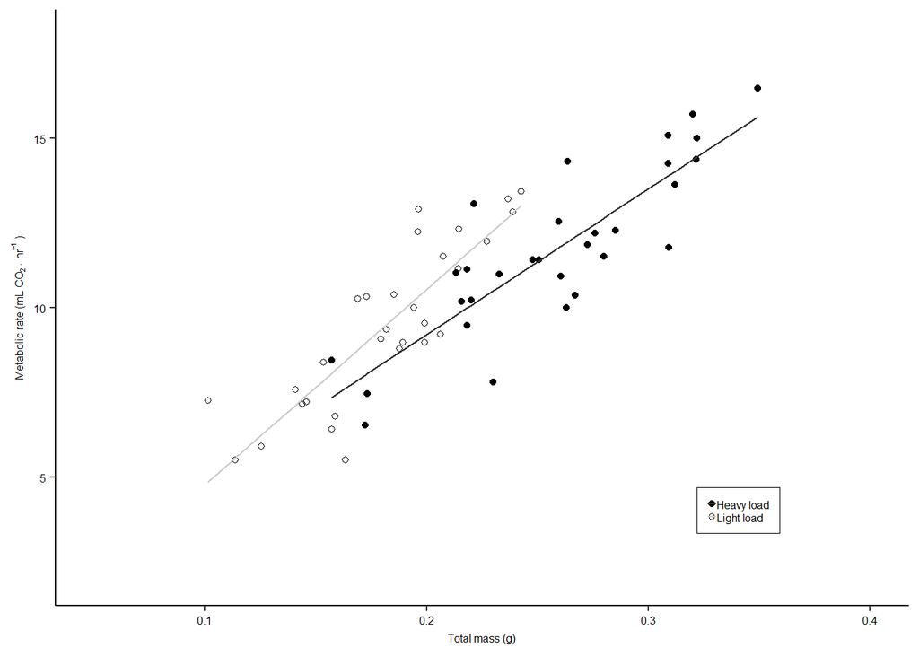

```r
#######################################################
## Metabolic Rate vs. loading conditions
#######################################################

# predict lines from m2
# make dataset for Fig 3a
fig3a_dta <- bdta %>%
  mutate(HighLowTrt = recode(.$treatment, "H" = "Heavy load",
                       "L" = "Light load"),
         predictedmetabolic_rate = predict(m1, re.form = NA)) %>%
  select(avg_mass, HighLowTrt, metabolic_rate, predictedmetabolic_rate)


# save data
# write_csv(fig3a_dta, file.path(dataOut, "Fig3AData.csv"))



fig3a <- ggplot(fig3a_dta, aes(x = avg_mass, y = metabolic_rate )) +
  geom_point(aes(shape = HighLowTrt)) +
  geom_line(aes(y = predictedmetabolic_rate, color = HighLowTrt), size = 0.5) +
  labs(y = expression("Metabolic rate (mL CO" [2] %.% ~ "hr"^{-1}~ ")" ),
       x = "Total mass (g)") +
  lims(x = c(0.05,0.4), y = c(2, 18)) +
  theme(legend.title = element_blank(),
        legend.background = element_rect(colour = "black", size = 0.3),
        legend.position = c(0.8, 0.16),
        legend.text = element_text(size = 6),
        axis.text = element_text(size = 6),
        axis.title = element_text(size = 6),
        legend.key.size = unit(0.2, "cm")) +
  scale_color_grey() +
  scale_shape_manual(values = c(16,1))

fig3a
```

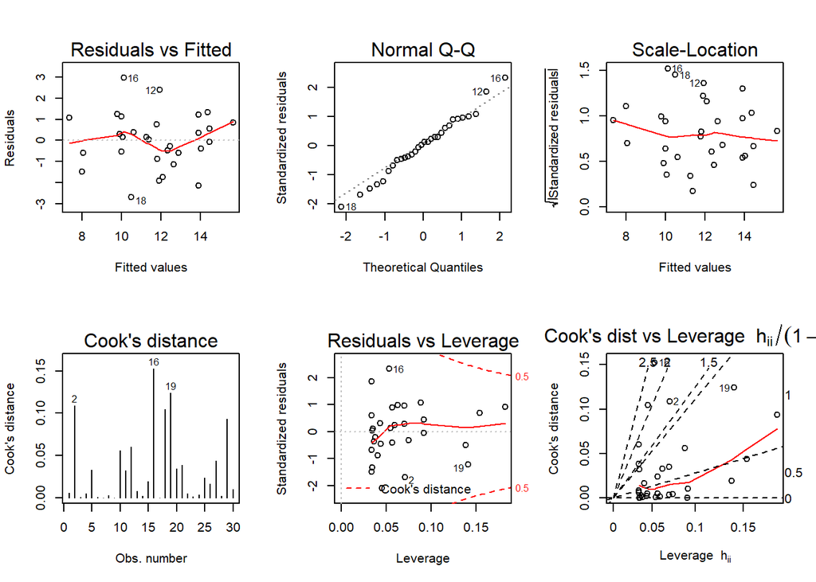

```r
# ggsave(filename = file.path(figDir, "fig3A.png"), width = 6.5/2, height = 2,
#         plot = fig3a,
#        units = "in", dpi = 500)





# calculate R^2 for heavy
mod1 <- lm(metabolic_rate_H ~ I(mass_starved + load_H), data = newDF)

# diagnostics
par(mfrow = c(2,3))
plot(mod1, which = 1:6)
```

```r
dev.off()
```

```r
summary(mod1)
```

```
##
## Call:
## lm(formula = metabolic_rate_H ~ I(mass_starved + load_H), data = newDF)
##
## Residuals:
##     Min      1Q  Median      3Q     Max
## -2.6912 -0.5972  0.0929  0.8161  2.9546
##
## Coefficients:
##                          Estimate Std. Error t value Pr(>|t|)
## (Intercept)                0.6051     1.3071   0.463    0.647
## I(mass_starved + load_H)  43.0258     4.9739   8.650 2.13e-09 ***
## ---
## Signif. codes:  0 '***' 0.001 '**' 0.01 '*' 0.05 '.' 0.1 ' ' 1
##
## Residual standard error: 1.306 on 28 degrees of freedom
## Multiple R-squared:  0.7277, Adjusted R-squared:  0.718
## F-statistic: 74.83 on 1 and 28 DF,  p-value: 2.132e-09
```

```r
# R^2 for light
mod2 <-  lm(metabolic_rate_L ~ I(mass_starved + load_L), data = newDF)
summary(mod2)
```

```
##
## Call:
## lm(formula = metabolic_rate_L ~ I(mass_starved + load_L), data = newDF)
##
## Residuals:
##     Min      1Q  Median      3Q     Max
## -2.9502 -0.8017 -0.1401  0.5937  2.5763
##
## Coefficients:
##                          Estimate Std. Error t value Pr(>|t|)
## (Intercept)               -0.8105     1.1967  -0.677    0.504
## I(mass_starved + load_L)  56.6946     6.4717   8.760 1.64e-09 ***
## ---
## Signif. codes:  0 '***' 0.001 '**' 0.01 '*' 0.05 '.' 0.1 ' ' 1
##
## Residual standard error: 1.259 on 28 degrees of freedom
## Multiple R-squared:  0.7327, Adjusted R-squared:  0.7231
## F-statistic: 76.74 on 1 and 28 DF,  p-value: 1.642e-09
```

```r
# diagnostics
par(mfrow = c(2,3))
plot(mod2, which = 1:6)
dev.off()
```

## Mass-specific metabolic rate versus percent loading

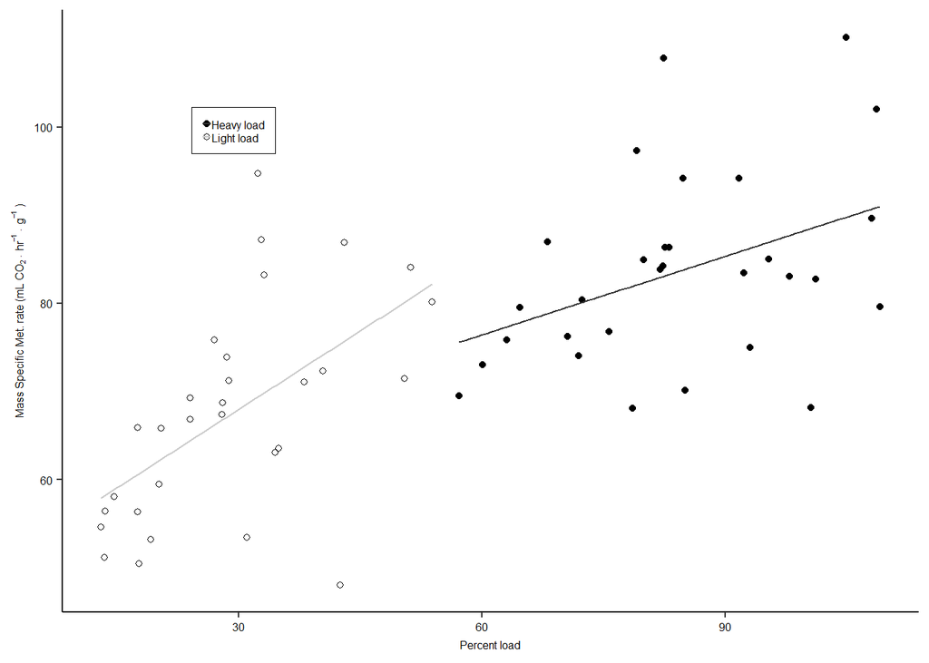

```r
#######################################################
### Mass-specific metabolic rate versus percent loading
#######################################################

# Plot mass-specific metabolic rate vs. percent loading
noFig <- bdta %>%
  mutate(Trt2 = recode(.$treatment, "H" = "Heavy load",
                       "L" = "Light load")) %>%
ggplot(aes(x = perc_load, y = mass_spec_metabolic_rate )) +
  geom_point(aes(shape = Trt2)) +
  stat_smooth(aes(color = Trt2), method = "lm", se = F, size = 0.5) +
  labs(y = expression("Mass Specific Met. rate (mL CO"
                      [2] %.% ~ "hr"^{-1} %.% ~ "g"^{-1}~ ")" ),
       x = "Percent load") +
  #lims(x = c(0.05,0.4), y = c(2, 18)) +
  theme(legend.title = element_blank(),
        legend.background = element_rect(colour = "black", size = 0.3),
        legend.position = c(0.2, 0.8),
        legend.text = element_text(size = 6),
        axis.text = element_text(size = 6),
        axis.title = element_text(size = 6),
        legend.key.size = unit(0.2, "cm")) +
  scale_color_grey() +
  scale_shape_manual(values = c(16,1))
noFig
```

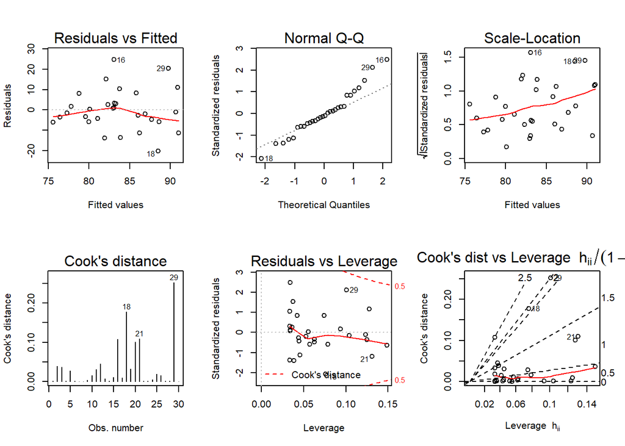

```r
# ggsave(filename = file.path(figDir, "mass_spec_metabolic_rateate.png"), width = 6.5/2, height = 2,
#         plot = noFig,
#        units = "in", dpi = 500)


# calculate R^2 for heavy
mod1 <- lm(mass_spec_metabolic_rate ~ perc_load, data = bdta[bdta$treatment == "H", ])
# diagnostics
par(mfrow = c(2,3))
plot(mod1, which = 1:6)
```

```r
dev.off()
```

```r
summary(mod1)
```

```
##
## Call:
## lm(formula = mass_spec_metabolic_rate ~ perc_load, data = bdta[bdta$treatment ==
##     "H", ])
##
## Residuals:
##     Min      1Q  Median      3Q     Max
## -20.348  -5.568  -1.296   3.165  24.759
##
## Coefficients:
##             Estimate Std. Error t value Pr(>|t|)
## (Intercept)  58.5950    10.9257   5.363 1.03e-05 ***
## perc_load     0.2970     0.1279   2.323   0.0277 *
## ---
## Signif. codes:  0 '***' 0.001 '**' 0.01 '*' 0.05 '.' 0.1 ' ' 1
##
## Residual standard error: 10.17 on 28 degrees of freedom
## Multiple R-squared:  0.1616, Adjusted R-squared:  0.1316
## F-statistic: 5.395 on 1 and 28 DF,  p-value: 0.02768
```

```r
with(bdta[bdta$treatment == "H", ], {
  plot(mass_spec_metabolic_rate ~ perc_load, pch = 20)
  lines(x = perc_load, y = predict(mod1))
})


mod2 <- lm(mass_spec_metabolic_rate ~ perc_load, data =  bdta[bdta$treatment == "L", ])
summary(mod2)
```

```
##
## Call:
## lm(formula = mass_spec_metabolic_rate ~ perc_load, data = bdta[bdta$treatment ==
##     "L", ])
##
## Residuals:
##     Min      1Q  Median      3Q     Max
## -27.383  -6.284  -1.248   4.581  25.362
##
## Coefficients:
##             Estimate Std. Error t value Pr(>|t|)
## (Intercept)  50.1615     5.1181   9.801  1.5e-10 ***
## perc_load     0.5935     0.1636   3.628  0.00113 **
## ---
## Signif. codes:  0 '***' 0.001 '**' 0.01 '*' 0.05 '.' 0.1 ' ' 1
##
## Residual standard error: 10.24 on 28 degrees of freedom
## Multiple R-squared:  0.3197, Adjusted R-squared:  0.2955
## F-statistic: 13.16 on 1 and 28 DF,  p-value: 0.001129
```

```r
# diagnostics
par(mfrow = c(2,3))
plot(mod2, which = 1:6)
dev.off()
```

```r
with(bdta[bdta$treatment == "L", ], {
  plot(mass_spec_metabolic_rate ~ perc_load)
  lines(x = perc_load, y = predict(mod2))
})
```

## Fig 3b

```r
m1 <- lmer((force) ~ treatment * I(scale(avg_mass)) + (1|bee_ID), data = bdta)
summary(m1)
```

```
## Linear mixed model fit by REML. t-tests use Satterthwaite's method [
## lmerModLmerTest]
## Formula: (force) ~ treatment * I(scale(avg_mass)) + (1 | bee_ID)
##    Data: bdta
##
## REML criterion at convergence: -758.6
##
## Scaled residuals:
##      Min       1Q   Median       3Q      Max
## -1.94576 -0.49271 -0.00456  0.61201  2.21732
##
## Random effects:
##  Groups   Name        Variance  Std.Dev.
##  bee_ID   (Intercept) 2.097e-08 0.0001448
##  Residual             4.401e-08 0.0002098
## Number of obs: 60, groups:  bee_ID, 30
##
## Fixed effects:
##                                Estimate Std. Error        df t value
## (Intercept)                   2.547e-03  5.955e-05 5.125e+01  42.765
## treatmentL                    4.163e-05  8.935e-05 5.375e+01   0.466
## I(scale(avg_mass))            6.903e-04  5.563e-05 5.221e+01  12.409
## treatmentL:I(scale(avg_mass)) 1.257e-04  7.838e-05 3.043e+01   1.604
##                               Pr(>|t|)
## (Intercept)                     <2e-16 ***
## treatmentL                       0.643
## I(scale(avg_mass))              <2e-16 ***
## treatmentL:I(scale(avg_mass))    0.119
## ---
## Signif. codes:  0 '***' 0.001 '**' 0.01 '*' 0.05 '.' 0.1 ' ' 1
##
## Correlation of Fixed Effects:
##             (Intr) trtmnL I((_))
## treatmentL  -0.644
## I(scl(vg_)) -0.624  0.590
## trtL:I((_))  0.258  0.242 -0.413
```

```r
car::vif(m1)
```

```
##                    treatment           I(scale(avg_mass))
##                     2.721493                     3.088086
## treatment:I(scale(avg_mass))
##                     2.139928
```

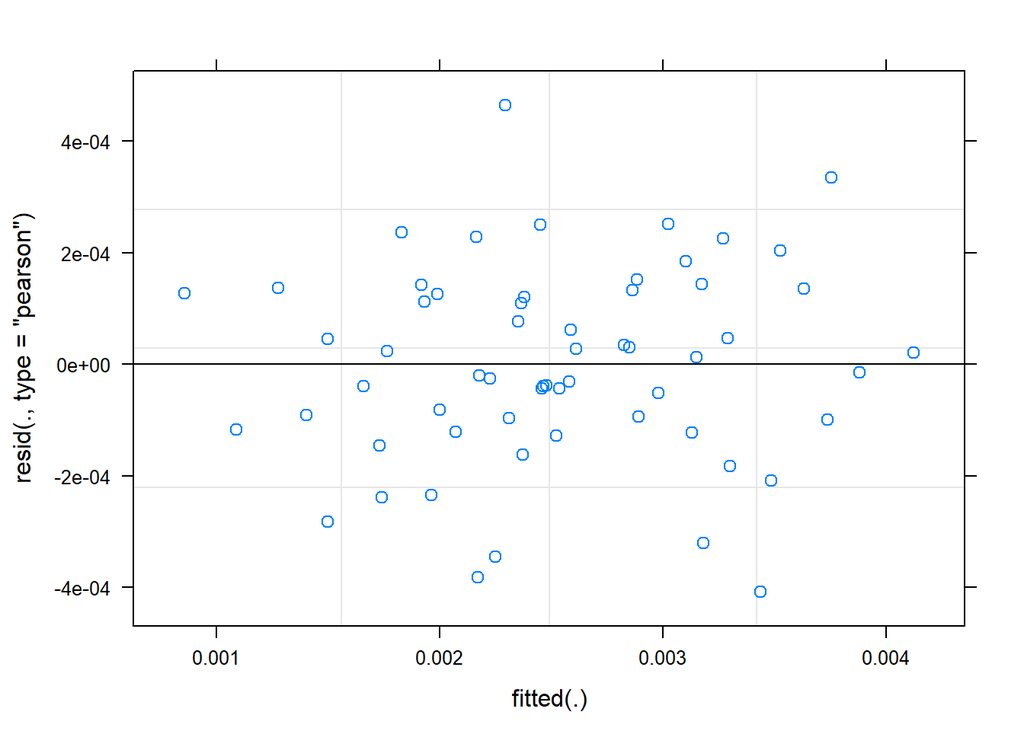

```r
plot(m1)
```

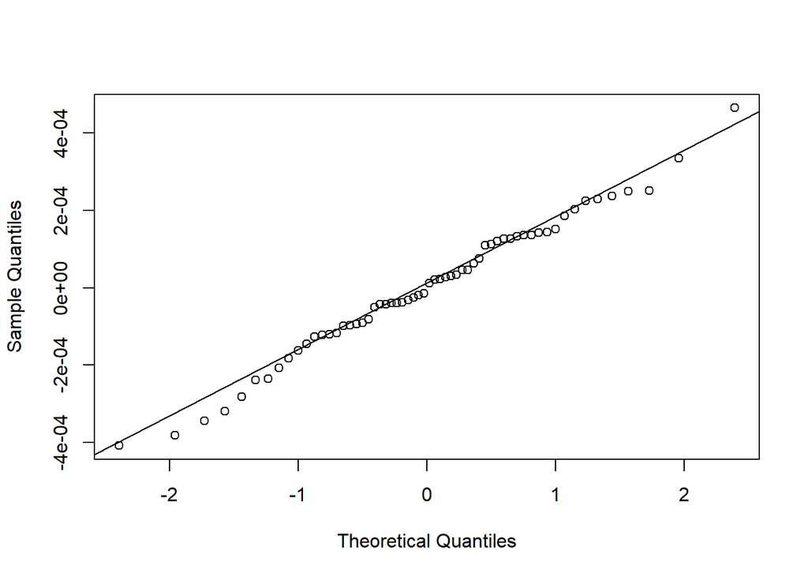

```r
# diagnostics
# qq plot
qqnorm(resid(m1), main = "")
qqline(resid(m1)) # good
```

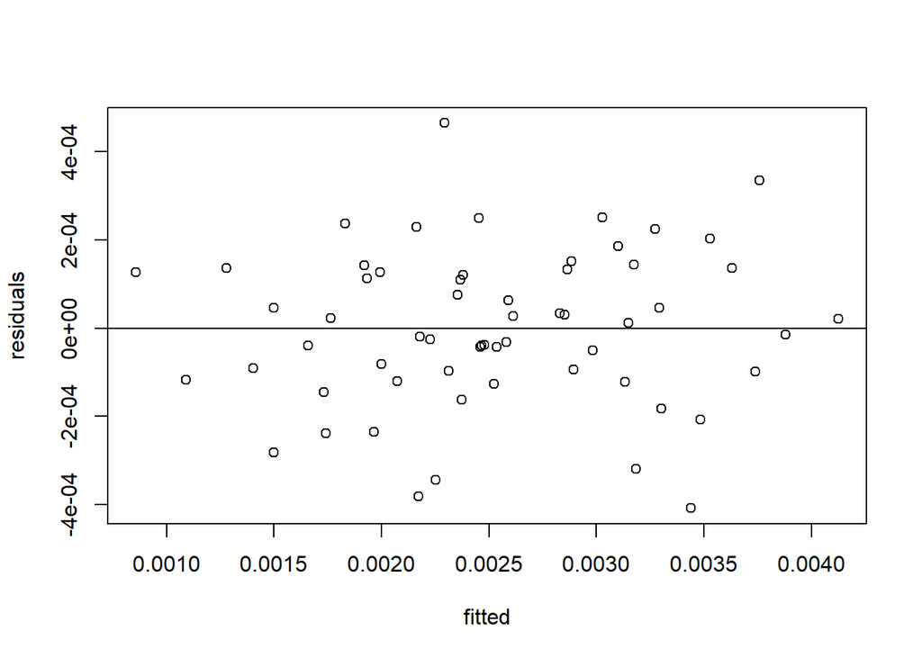

```r
# residual plot
plot(fitted(m1), resid(m1), xlab = "fitted", ylab = "residuals")
abline(0,0)
```

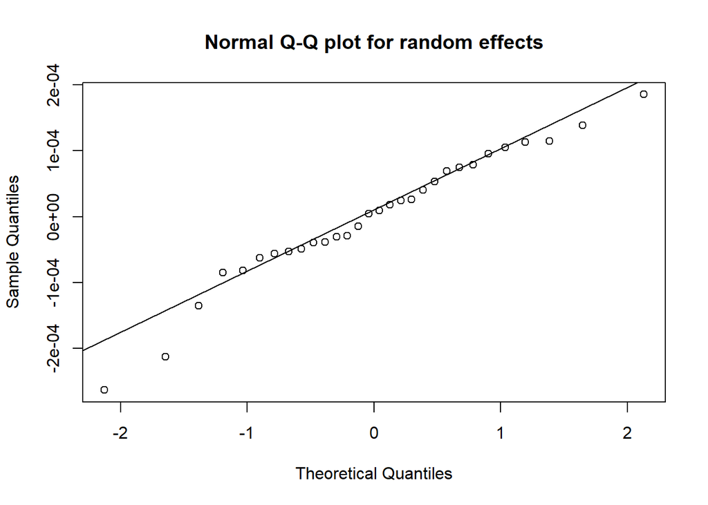

```r
# QQPlot for group-level effects
qqnorm(ranef(m1)$bee_ID[[1]], main="Normal Q-Q plot for random effects")
qqline(ranef(m1)$bee_ID[[1]]) # looks good
```

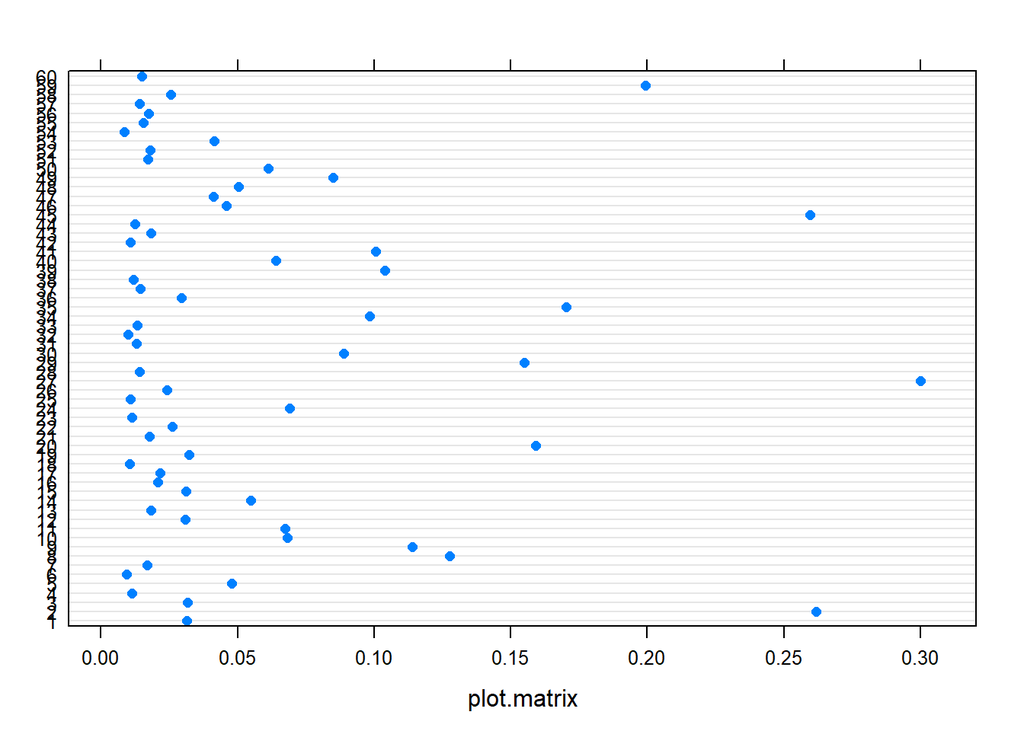

```r
infl <- influence(m1, obs = TRUE)
plot(infl, which = 'cook')
```

```r
m2 <- update(m1, .~. - treatment : I(scale(avg_mass)))
anova(m2, m1, test = "LRT")
```

```
## refitting model(s) with ML (instead of REML)
```

```
## Data: bdta
## Models:
## m2: (force) ~ treatment + I(scale(avg_mass)) + (1 | bee_ID)
## m1: (force) ~ treatment * I(scale(avg_mass)) + (1 | bee_ID)
##    Df     AIC     BIC logLik deviance  Chisq Chi Df Pr(>Chisq)
## m2  5 -817.49 -807.02 413.74  -827.49
## m1  6 -818.12 -805.55 415.06  -830.12 2.6327      1     0.1047
```

```r
summary(m2)
```

```
## Linear mixed model fit by REML. t-tests use Satterthwaite's method [
## lmerModLmerTest]
## Formula: (force) ~ treatment + I(scale(avg_mass)) + (1 | bee_ID)
##    Data: bdta
##
## REML criterion at convergence: -773.2
##
## Scaled residuals:
##      Min       1Q   Median       3Q      Max
## -2.15220 -0.55286 -0.01893  0.59210  2.25363
##
## Random effects:
##  Groups   Name        Variance  Std.Dev.
##  bee_ID   (Intercept) 1.951e-08 0.0001397
##  Residual             4.657e-08 0.0002158
## Number of obs: 60, groups:  bee_ID, 30
##
## Fixed effects:
##                     Estimate Std. Error        df t value Pr(>|t|)
## (Intercept)        2.523e-03  5.787e-05 4.555e+01  43.592  < 2e-16 ***
## treatmentL         6.205e-06  8.768e-05 5.618e+01   0.071    0.944
## I(scale(avg_mass)) 7.266e-04  5.067e-05 3.247e+01  14.339 1.34e-15 ***
## ---
## Signif. codes:  0 '***' 0.001 '**' 0.01 '*' 0.05 '.' 0.1 ' ' 1
##
## Correlation of Fixed Effects:
##             (Intr) trtmnL
## treatmentL  -0.758
## I(scl(vg_)) -0.585  0.772
```

```r
# treatment is not significant
m3 <- update(m2, .~. - treatment)
anova(m2, m3, test = "LRT")
```

```
## refitting model(s) with ML (instead of REML)
```

```
## Data: bdta
## Models:
## m3: (force) ~ I(scale(avg_mass)) + (1 | bee_ID)
## m2: (force) ~ treatment + I(scale(avg_mass)) + (1 | bee_ID)
##    Df     AIC     BIC logLik deviance  Chisq Chi Df Pr(>Chisq)
## m3  4 -819.48 -811.11 413.74  -827.48
## m2  5 -817.49 -807.02 413.74  -827.49 0.0047      1     0.9451
```

```r
summary(m3)
```

```
## Linear mixed model fit by REML. t-tests use Satterthwaite's method [
## lmerModLmerTest]
## Formula: (force) ~ I(scale(avg_mass)) + (1 | bee_ID)
##    Data: bdta
##
## REML criterion at convergence: -790
##
## Scaled residuals:
##      Min       1Q   Median       3Q      Max
## -2.17249 -0.55164 -0.02367  0.59976  2.27987
##
## Random effects:
##  Groups   Name        Variance  Std.Dev.
##  bee_ID   (Intercept) 1.901e-08 0.0001379
##  Residual             4.589e-08 0.0002142
## Number of obs: 60, groups:  bee_ID, 30
##
## Fixed effects:
##                     Estimate Std. Error        df t value Pr(>|t|)
## (Intercept)        2.526e-03  3.740e-05 2.885e+01   67.54   <2e-16 ***
## I(scale(avg_mass)) 7.238e-04  3.194e-05 5.500e+01   22.66   <2e-16 ***
## ---
## Signif. codes:  0 '***' 0.001 '**' 0.01 '*' 0.05 '.' 0.1 ' ' 1
##
## Correlation of Fixed Effects:
##             (Intr)
## I(scl(vg_)) 0.000
```

```r
m3 <- update(m2, force ~ avg_mass + (1|bee_ID))
summary(m3)
```

```
## Linear mixed model fit by REML. t-tests use Satterthwaite's method [
## lmerModLmerTest]
## Formula: force ~ avg_mass + (1 | bee_ID)
##    Data: bdta
##
## REML criterion at convergence: -795.7
##
## Scaled residuals:
##      Min       1Q   Median       3Q      Max
## -2.17249 -0.55164 -0.02367  0.59976  2.27987
##
## Random effects:
##  Groups   Name        Variance  Std.Dev.
##  bee_ID   (Intercept) 1.901e-08 0.0001379
##  Residual             4.589e-08 0.0002142
## Number of obs: 60, groups:  bee_ID, 30
##
## Fixed effects:
##               Estimate Std. Error         df t value Pr(>|t|)
## (Intercept) -0.0002390  0.0001276 57.0756311  -1.873   0.0661 .
## avg_mass     0.0125712  0.0005547 54.9962502  22.665   <2e-16 ***
## ---
## Signif. codes:  0 '***' 0.001 '**' 0.01 '*' 0.05 '.' 0.1 ' ' 1
##
## Correlation of Fixed Effects:
##          (Intr)
## avg_mass -0.956
```

```r
m4 <- update(m3, .~. - avg_mass)
anova(m3, m4, test = "LRT")
```

```
## refitting model(s) with ML (instead of REML)
```

```
## Data: bdta
## Models:
## m4: force ~ (1 | bee_ID)
## m3: force ~ avg_mass + (1 | bee_ID)
##    Df     AIC     BIC logLik deviance  Chisq Chi Df Pr(>Chisq)
## m4  3 -685.90 -679.62 345.95  -691.90
## m3  4 -819.48 -811.11 413.74  -827.48 135.58      1  < 2.2e-16 ***
## ---
## Signif. codes:  0 '***' 0.001 '**' 0.01 '*' 0.05 '.' 0.1 ' ' 1
```

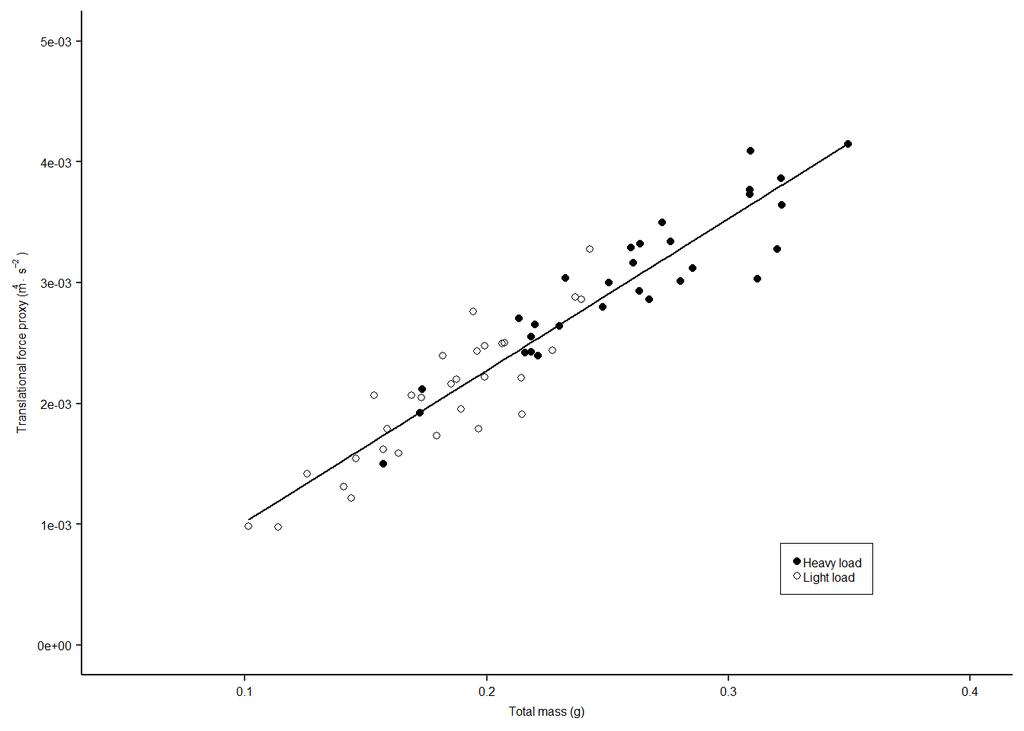

```r
# Plot force vs. body mass + load
fig3b_dta <- bdta %>%
  mutate(Trt2 = recode(.$treatment, "H" = "Heavy load",
                       "L" = "Light load"))


# make dataset for Fig 3a
fig3b_dta <- bdta %>%
  mutate(HighLowTrt = recode(.$treatment, "H" = "Heavy load",
                       "L" = "Light load"),
         predictedTransForce = (predict(m3, re.form = NA))) %>%
  select(avg_mass, HighLowTrt, force, predictedTransForce)

# save data
#write_csv(fig3b_dta, file.path(dataOut, "Fig3BData.csv"))


fig3b <- ggplot(fig3b_dta, aes(x = avg_mass, y = force )) +
  geom_point(aes(shape = HighLowTrt)) +
  #stat_smooth(aes(color = HighLowTrt), method = "lm", se = F, size = 0.5) +
  geom_line(aes(y = predictedTransForce), color = "black", size = 0.5) +
  labs(y = expression("Translational force proxy (m"^4 %.% ~ "s"^{-2}~ ")" ),
       x = "Total mass (g)") +
  lims(x = c(0.05,0.4)) +
  theme(legend.title = element_blank(),
        legend.background = element_rect(colour = "black", size = 0.3),
        legend.position = c(0.8, 0.16),
        legend.text = element_text(size = 6),
        axis.text = element_text(size = 6),
        axis.title = element_text(size = 6),
        legend.key.size = unit(0.2, "cm")) +
  scale_color_grey() +
  scale_shape_manual(values = c(16,1)) +
  scale_y_continuous(labels = scales::scientific, limits = c(0, 5e-3))

fig3b
```

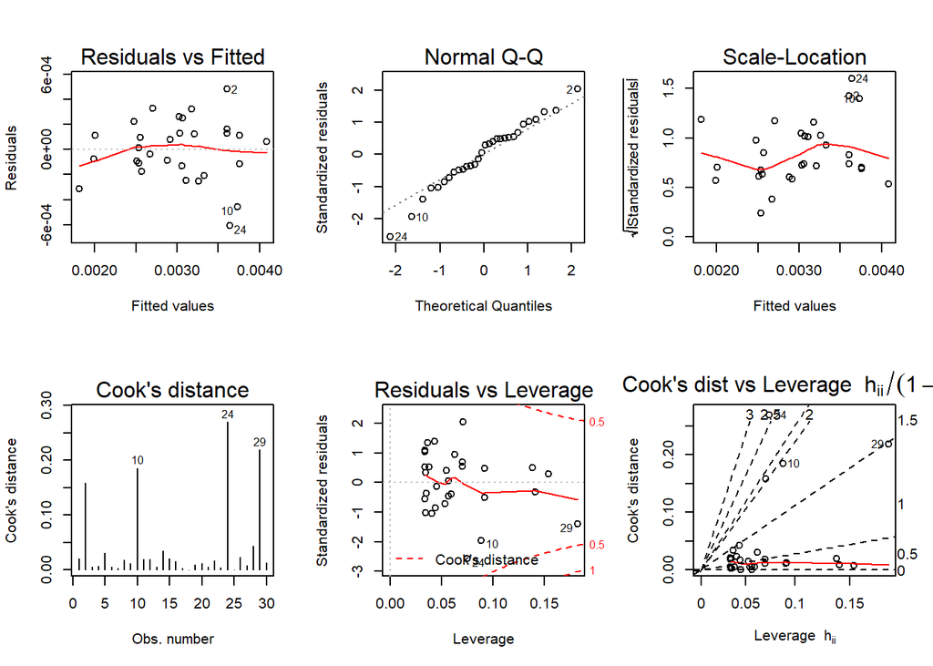

```r
# ggsave(filename = file.path(figDir, "fig3B.png"), width = 6.5/2, height = 2,
#         plot = fig3b,
#        units = "in", dpi = 500)


# calculate R^2 for heavy
mod1 <- lm(force ~ avg_mass, data = bdta[bdta$treatment == "H", ])
# diagnostics
par(mfrow = c(2,3))
plot(mod1, which = 1:6)
```

```r
dev.off()
```

```r
(summ <- summary(mod1))
```

```
##
## Call:
## lm(formula = force ~ avg_mass, data = bdta[bdta$treatment ==
##     "H", ])
##
## Residuals:
##        Min         1Q     Median         3Q        Max
## -6.101e-04 -1.281e-04  3.901e-05  1.288e-04  4.840e-04
##
## Coefficients:
##               Estimate Std. Error t value Pr(>|t|)
## (Intercept) -3.745e-05  2.464e-04  -0.152     0.88
## avg_mass     1.179e-02  9.377e-04  12.570 4.95e-13 ***
## ---
## Signif. codes:  0 '***' 0.001 '**' 0.01 '*' 0.05 '.' 0.1 ' ' 1
##
## Residual standard error: 0.0002463 on 28 degrees of freedom
## Multiple R-squared:  0.8495, Adjusted R-squared:  0.8441
## F-statistic:   158 on 1 and 28 DF,  p-value: 4.946e-13
```

```r
summ$r.squared
```

```
## [1] 0.8494659
```

```r
mod2 <- lm((force) ~ avg_mass, data =  bdta[bdta$treatment == "L", ])
summary(mod2)
```

```
##
## Call:
## lm(formula = (force) ~ avg_mass, data = bdta[bdta$treatment ==
##     "L", ])
##
## Residuals:
##        Min         1Q     Median         3Q        Max
## -0.0006005 -0.0001914  0.0000574  0.0001426  0.0005373
##
## Coefficients:
##               Estimate Std. Error t value Pr(>|t|)
## (Intercept) -0.0004879  0.0002499  -1.952    0.061 .
## avg_mass     0.0139497  0.0013516  10.321 4.77e-11 ***
## ---
## Signif. codes:  0 '***' 0.001 '**' 0.01 '*' 0.05 '.' 0.1 ' ' 1
##
## Residual standard error: 0.000263 on 28 degrees of freedom
## Multiple R-squared:  0.7918, Adjusted R-squared:  0.7844
## F-statistic: 106.5 on 1 and 28 DF,  p-value: 4.772e-11
```

```r
summary(mod2)$r.squared
```

```
## [1] 0.7918499
```

```r
# diagnostics
par(mfrow = c(2,3))
plot(mod2, which = 1:6)
dev.off()
```

# Fig 4: Change in freq and amplitude

### 4a: Change in %load vs. change in amplitude

```r
# calculate mean and SD
tapply(bdta$amp, INDEX = bdta$treatment,
       function(x) return(c(mean(x), sd(x))))
```

```
## $H
## [1] 133.44981   5.51554
##
## $L
## [1] 113.161785   7.968646
```

```r
# fit full model
m1 <- lm(delta_amp ~  (I(scale(delta_perc_load)) +  I(scale(IT_span_mm)) + order_1)^2, data = newDF)
summary(m1)
```

```
##
## Call:
## lm(formula = delta_amp ~ (I(scale(delta_perc_load)) + I(scale(IT_span_mm)) +
##     order_1)^2, data = newDF)
##
## Residuals:
##      Min       1Q   Median       3Q      Max
## -13.0312  -4.5228   0.2458   5.0488  11.8076
##
## Coefficients:
##                                                Estimate Std. Error t value
## (Intercept)                                      20.696      2.733   7.572
## I(scale(delta_perc_load))                         5.391      2.753   1.958
## I(scale(IT_span_mm))                             -2.722      3.148  -0.865
## order_1loadedSecond                              -0.712      3.981  -0.179
## I(scale(delta_perc_load)):I(scale(IT_span_mm))    2.304      2.547   0.905
## I(scale(delta_perc_load)):order_1loadedSecond    -1.526      4.230  -0.361
## I(scale(IT_span_mm)):order_1loadedSecond          2.300      5.587   0.412
##                                                Pr(>|t|)
## (Intercept)                                    1.09e-07 ***
## I(scale(delta_perc_load))                        0.0624 .
## I(scale(IT_span_mm))                             0.3960
## order_1loadedSecond                              0.8596
## I(scale(delta_perc_load)):I(scale(IT_span_mm))   0.3751
## I(scale(delta_perc_load)):order_1loadedSecond    0.7216
## I(scale(IT_span_mm)):order_1loadedSecond         0.6843
## ---
## Signif. codes:  0 '***' 0.001 '**' 0.01 '*' 0.05 '.' 0.1 ' ' 1
##
## Residual standard error: 7.296 on 23 degrees of freedom
## Multiple R-squared:  0.4175, Adjusted R-squared:  0.2656
## F-statistic: 2.748 on 6 and 23 DF,  p-value: 0.03662
```

```r
car::vif(m1) # too high
```

```
##                      I(scale(delta_perc_load))
##                                       4.128844
##                           I(scale(IT_span_mm))
##                                       5.397750
##                                        order_1
##                                       2.223096
## I(scale(delta_perc_load)):I(scale(IT_span_mm))
##                                       4.373161
##              I(scale(delta_perc_load)):order_1
##                                       2.970918
##                   I(scale(IT_span_mm)):order_1
##                                       8.366747
```

```r
# remove variables because of high VIF
m2 <- update(m1, .~. -  I(scale(IT_span_mm)):order_1)
car::vif(m2)
```

```
##                      I(scale(delta_perc_load))
##                                       4.034831
##                           I(scale(IT_span_mm))
##                                       1.140357
##                                        order_1
##                                       2.147897
## I(scale(delta_perc_load)):I(scale(IT_span_mm))
##                                       1.172550
##              I(scale(delta_perc_load)):order_1
##                                       2.942812
```

```r
# now VIF is okay
summary(m2)
```

```
##
## Call:
## lm(formula = delta_amp ~ I(scale(delta_perc_load)) + I(scale(IT_span_mm)) +
##     order_1 + I(scale(delta_perc_load)):I(scale(IT_span_mm)) +
##     I(scale(delta_perc_load)):order_1, data = newDF)
##
## Residuals:
##      Min       1Q   Median       3Q      Max
## -12.6721  -4.4220  -0.2386   4.8543  12.3608
##
## Coefficients:
##                                                Estimate Std. Error t value
## (Intercept)                                      20.638      2.682   7.695
## I(scale(delta_perc_load))                         5.220      2.674   1.952
## I(scale(IT_span_mm))                             -1.571      1.422  -1.105
## order_1loadedSecond                              -1.014      3.845  -0.264
## I(scale(delta_perc_load)):I(scale(IT_span_mm))    1.407      1.296   1.086
## I(scale(delta_perc_load)):order_1loadedSecond    -1.695      4.137  -0.410
##                                                Pr(>|t|)
## (Intercept)                                    6.23e-08 ***
## I(scale(delta_perc_load))                        0.0627 .
## I(scale(IT_span_mm))                             0.2800
## order_1loadedSecond                              0.7943
## I(scale(delta_perc_load)):I(scale(IT_span_mm))   0.2885
## I(scale(delta_perc_load)):order_1loadedSecond    0.6856
## ---
## Signif. codes:  0 '***' 0.001 '**' 0.01 '*' 0.05 '.' 0.1 ' ' 1
##
## Residual standard error: 7.169 on 24 degrees of freedom
## Multiple R-squared:  0.4132, Adjusted R-squared:  0.291
## F-statistic: 3.381 on 5 and 24 DF,  p-value: 0.0188
```

```r
m3 <- update(m2, .~. - I(scale(delta_perc_load)):order_1)
summary(m3)
```

```
##
## Call:
## lm(formula = delta_amp ~ I(scale(delta_perc_load)) + I(scale(IT_span_mm)) +
##     order_1 + I(scale(delta_perc_load)):I(scale(IT_span_mm)),
##     data = newDF)
##
## Residuals:
##      Min       1Q   Median       3Q      Max
## -13.0163  -4.0997  -0.8189   4.2260  12.1299
##
## Coefficients:
##                                                Estimate Std. Error t value
## (Intercept)                                     21.1116     2.3795   8.872
## I(scale(delta_perc_load))                        4.5154     2.0129   2.243
## I(scale(IT_span_mm))                            -1.5334     1.3947  -1.099
## order_1loadedSecond                             -0.8861     3.7680  -0.235
## I(scale(delta_perc_load)):I(scale(IT_span_mm))   1.2266     1.1985   1.023
##                                                Pr(>|t|)
## (Intercept)                                    3.39e-09 ***
## I(scale(delta_perc_load))                         0.034 *
## I(scale(IT_span_mm))                              0.282
## order_1loadedSecond                               0.816
## I(scale(delta_perc_load)):I(scale(IT_span_mm))    0.316
## ---
## Signif. codes:  0 '***' 0.001 '**' 0.01 '*' 0.05 '.' 0.1 ' ' 1
##
## Residual standard error: 7.048 on 25 degrees of freedom
## Multiple R-squared:  0.4091, Adjusted R-squared:  0.3146
## F-statistic: 4.328 on 4 and 25 DF,  p-value: 0.008509
```

```r
anova(m2, m3)
```

```
## Analysis of Variance Table
##
## Model 1: delta_amp ~ I(scale(delta_perc_load)) + I(scale(IT_span_mm)) +
##     order_1 + I(scale(delta_perc_load)):I(scale(IT_span_mm)) +
##     I(scale(delta_perc_load)):order_1
## Model 2: delta_amp ~ I(scale(delta_perc_load)) + I(scale(IT_span_mm)) +
##     order_1 + I(scale(delta_perc_load)):I(scale(IT_span_mm))
##   Res.Df    RSS Df Sum of Sq      F Pr(>F)
## 1     24 1233.4
## 2     25 1242.0 -1   -8.6289 0.1679 0.6856
```

```r
m4 <- update(m3, .~. - I(scale(delta_perc_load)):I(scale(IT_span_mm)))
anova(m3, m4)
```

```
## Analysis of Variance Table
##
## Model 1: delta_amp ~ I(scale(delta_perc_load)) + I(scale(IT_span_mm)) +
##     order_1 + I(scale(delta_perc_load)):I(scale(IT_span_mm))
## Model 2: delta_amp ~ I(scale(delta_perc_load)) + I(scale(IT_span_mm)) +
##     order_1
##   Res.Df  RSS Df Sum of Sq      F Pr(>F)
## 1     25 1242
## 2     26 1294 -1   -52.031 1.0473 0.3159
```

```r
summary(m4)
```

```
##
## Call:
## lm(formula = delta_amp ~ I(scale(delta_perc_load)) + I(scale(IT_span_mm)) +
##     order_1, data = newDF)
##
## Residuals:
##      Min       1Q   Median       3Q      Max
## -12.6002  -4.0943  -0.6287   5.5626  11.6893
##
## Coefficients:
##                           Estimate Std. Error t value Pr(>|t|)
## (Intercept)                 20.984      2.378   8.823 2.69e-09 ***
## I(scale(delta_perc_load))    4.157      1.984   2.095    0.046 *
## I(scale(IT_span_mm))        -1.517      1.396  -1.087    0.287
## order_1loadedSecond         -1.305      3.749  -0.348    0.730
## ---
## Signif. codes:  0 '***' 0.001 '**' 0.01 '*' 0.05 '.' 0.1 ' ' 1
##
## Residual standard error: 7.055 on 26 degrees of freedom
## Multiple R-squared:  0.3844, Adjusted R-squared:  0.3134
## F-statistic: 5.412 on 3 and 26 DF,  p-value: 0.00499
```

```r
m5 <- update(m4, .~. - order_1)
anova(m4,m5)
```

```
## Analysis of Variance Table
##
## Model 1: delta_amp ~ I(scale(delta_perc_load)) + I(scale(IT_span_mm)) +
##     order_1
## Model 2: delta_amp ~ I(scale(delta_perc_load)) + I(scale(IT_span_mm))
##   Res.Df  RSS Df Sum of Sq      F Pr(>F)
## 1     26 1294
## 2     27 1300 -1   -6.0351 0.1213 0.7305
```

```r
summary(m5)
```

```
##
## Call:
## lm(formula = delta_amp ~ I(scale(delta_perc_load)) + I(scale(IT_span_mm)),
##     data = newDF)
##
## Residuals:
##     Min      1Q  Median      3Q     Max
## -13.085  -3.742  -0.925   5.380  12.305
##
## Coefficients:
##                           Estimate Std. Error t value Pr(>|t|)
## (Intercept)                 20.288      1.267  16.014 2.61e-15 ***
## I(scale(delta_perc_load))    4.657      1.349   3.452  0.00185 **
## I(scale(IT_span_mm))        -1.427      1.349  -1.057  0.29966
## ---
## Signif. codes:  0 '***' 0.001 '**' 0.01 '*' 0.05 '.' 0.1 ' ' 1
##
## Residual standard error: 6.939 on 27 degrees of freedom
## Multiple R-squared:  0.3815, Adjusted R-squared:  0.3357
## F-statistic: 8.328 on 2 and 27 DF,  p-value: 0.001524
```

```r
m6 <- update(m5, .~. -I(scale(IT_span_mm)) )
summary(m6)
```

```
##
## Call:
## lm(formula = delta_amp ~ I(scale(delta_perc_load)), data = newDF)
##
## Residuals:
##      Min       1Q   Median       3Q      Max
## -13.1149  -4.8780  -0.5095   4.3806  14.1740
##
## Coefficients:
##                           Estimate Std. Error t value Pr(>|t|)
## (Intercept)                 20.288      1.270  15.980 1.33e-15 ***
## I(scale(delta_perc_load))    5.079      1.291   3.933 0.000502 ***
## ---
## Signif. codes:  0 '***' 0.001 '**' 0.01 '*' 0.05 '.' 0.1 ' ' 1
##
## Residual standard error: 6.954 on 28 degrees of freedom
## Multiple R-squared:  0.3559, Adjusted R-squared:  0.3329
## F-statistic: 15.47 on 1 and 28 DF,  p-value: 0.0005022
```

```r
anova(m5, m6)
```

```
## Analysis of Variance Table
##
## Model 1: delta_amp ~ I(scale(delta_perc_load)) + I(scale(IT_span_mm))
## Model 2: delta_amp ~ I(scale(delta_perc_load))
##   Res.Df    RSS Df Sum of Sq      F Pr(>F)
## 1     27 1300.0
## 2     28 1353.9 -1   -53.844 1.1183 0.2997
```

```r
# final model for paper
m6 <- update(m6, .~ delta_perc_load)
summary(m6)
```

```
##
## Call:
## lm(formula = delta_amp ~ delta_perc_load, data = newDF)
##
## Residuals:
##      Min       1Q   Median       3Q      Max
## -13.1149  -4.8780  -0.5095   4.3806  14.1740
##
## Coefficients:
##                 Estimate Std. Error t value Pr(>|t|)
## (Intercept)     -10.3904     7.9021  -1.315 0.199214
## delta_perc_load   0.5570     0.1416   3.933 0.000502 ***
## ---
## Signif. codes:  0 '***' 0.001 '**' 0.01 '*' 0.05 '.' 0.1 ' ' 1
##
## Residual standard error: 6.954 on 28 degrees of freedom
## Multiple R-squared:  0.3559, Adjusted R-squared:  0.3329
## F-statistic: 15.47 on 1 and 28 DF,  p-value: 0.0005022
```

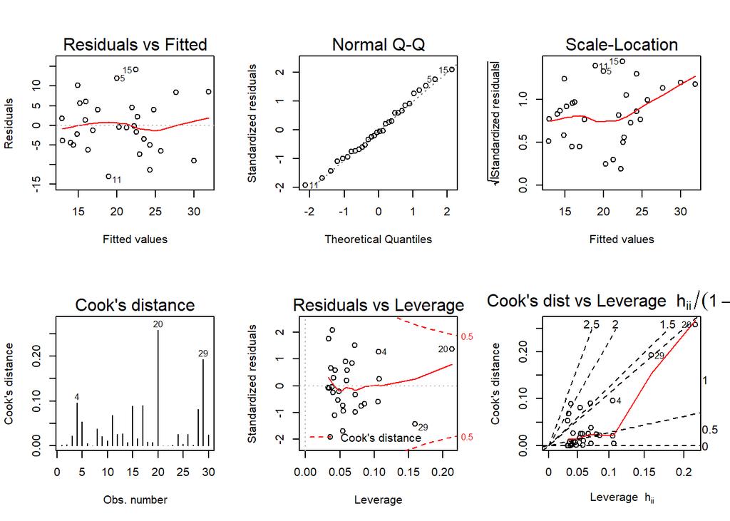

```r
#write.table(as.data.frame(summary(m6)$coef),"clipboard",sep="\t")

# diagnostics
par(mfrow = c(2,3))
plot(m6, which = 1:6)
```

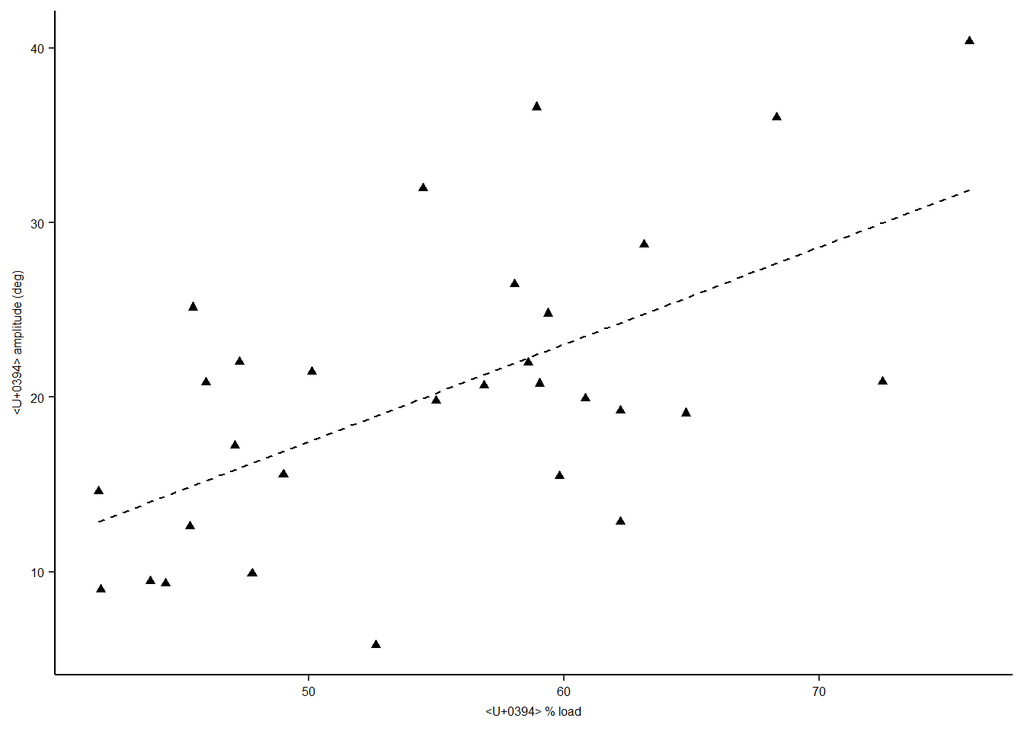

```r
par(mfrow = c(1,1))

# Note that the t-stat^2 is the same as a partial f-test

### model visualization -- no need to use partial residuals, since
### there is only one predictor



fig4a <- ggplot(newDF, aes(x= delta_perc_load, y = delta_amp)) +
  geom_point(shape = 17) +
  labs(x = "Δ % load", y = "Δ amplitude (deg)" ) +
  stat_smooth(method = 'lm', se = FALSE, color = "black", lty = 2, size = 0.5) +
  #scale_y_continuous(labels = scales::scientific, limits = c(-15, 25)) +
  theme(legend.title = element_blank(),
        legend.background = element_rect(colour = "black", size = 0.3),
        legend.position = c(0.8, 0.16),
        legend.text = element_text(size = 6),
        axis.text = element_text(size = 6),
        axis.title = element_text(size = 6),
        legend.key.size = unit(0.2, "cm"))
fig4a
```

```r
# ggsave(filename = file.path(figDir, "fig4a.png"), width = 6.5/2, height = 2,
#         plot = fig4a,
#        units = "in", dpi = 500)


# calculate correlation coefficient
cor(newDF$delta_amp, newDF$delta_perc_load)**2
```

```
## [1] 0.3559028
```

### change in freq vs. delta perc load

```r
# how many trials increased
newDF$FreqHigherInHeavy <- (newDF$freq_H - newDF$freq_L) > 0
summary(newDF$FreqHigherInHeavy)
```

```
##    Mode   FALSE    TRUE
## logical       7      23
```

```r
sum(newDF$FreqHigherInHeavy) / nrow(newDF)
```

```
## [1] 0.7666667
```

```r
# which treatment did freq decline
tapply(newDF$FreqHigherInHeavy, INDEX = newDF$order_1, summary)
```

```
## $loadedFirst
##    Mode    TRUE
## logical      14
##
## $loadedSecond
##    Mode   FALSE    TRUE
## logical       7       9
```

```r
# calculate mean + sd for each treatment
tapply(bdta$freq, INDEX = bdta$treatment, function(x) c(mean(x), sd(x)))
```

```
## $H
## [1] 183.177950   7.725096
##
## $L
## [1] 176.797978   9.631946
```

```r
# visualize data to see where bees decreased frequency
# ggplot(newDF, aes(y = delta_freq, x = order_1)) +
#          geom_point(aes(color = delta_freq < 0)) +
#   geom_text(aes(label=bee_ID),hjust=0.1, vjust=0, position= position_jitter())


# fit full model
m1 <- lm(delta_freq ~  (I(scale(delta_perc_load)) +  I(scale(IT_span_mm)) + order_1)^2, data = newDF)
summary(m1)
```

```
##
## Call:
## lm(formula = delta_freq ~ (I(scale(delta_perc_load)) + I(scale(IT_span_mm)) +
##     order_1)^2, data = newDF)
##
## Residuals:
##     Min      1Q  Median      3Q     Max
## -8.8835 -6.0090 -0.4143  5.5721 11.5282
##
## Coefficients:
##                                                Estimate Std. Error t value
## (Intercept)                                      13.408      2.545   5.268
## I(scale(delta_perc_load))                        -4.707      2.563  -1.836
## I(scale(IT_span_mm))                              1.073      2.931   0.366
## order_1loadedSecond                             -12.993      3.707  -3.505
## I(scale(delta_perc_load)):I(scale(IT_span_mm))   -2.103      2.371  -0.887
## I(scale(delta_perc_load)):order_1loadedSecond     1.620      3.939   0.411
## I(scale(IT_span_mm)):order_1loadedSecond         -3.133      5.203  -0.602
##                                                Pr(>|t|)
## (Intercept)                                     2.4e-05 ***
## I(scale(delta_perc_load))                        0.0793 .
## I(scale(IT_span_mm))                             0.7176
## order_1loadedSecond                              0.0019 **
## I(scale(delta_perc_load)):I(scale(IT_span_mm))   0.3844
## I(scale(delta_perc_load)):order_1loadedSecond    0.6847
## I(scale(IT_span_mm)):order_1loadedSecond         0.5529
## ---
## Signif. codes:  0 '***' 0.001 '**' 0.01 '*' 0.05 '.' 0.1 ' ' 1
##
## Residual standard error: 6.794 on 23 degrees of freedom
## Multiple R-squared:  0.3755, Adjusted R-squared:  0.2126
## F-statistic: 2.305 on 6 and 23 DF,  p-value: 0.06883
```

```r
car::vif(m1) # too high
```

```
##                      I(scale(delta_perc_load))
##                                       4.128844
##                           I(scale(IT_span_mm))
##                                       5.397750
##                                        order_1
##                                       2.223096
## I(scale(delta_perc_load)):I(scale(IT_span_mm))
##                                       4.373161
##              I(scale(delta_perc_load)):order_1
##                                       2.970918
##                   I(scale(IT_span_mm)):order_1
##                                       8.366747
```

```r
# remove variables because of high VIF
m2 <- update(m1, .~. - I(scale(IT_span_mm)):order_1)
car::vif(m2)
```

```
##                      I(scale(delta_perc_load))
##                                       4.034831
##                           I(scale(IT_span_mm))
##                                       1.140357
##                                        order_1
##                                       2.147897
## I(scale(delta_perc_load)):I(scale(IT_span_mm))
##                                       1.172550
##              I(scale(delta_perc_load)):order_1
##                                       2.942812
```

```r
summary(m2)
```

```
##
## Call:
## lm(formula = delta_freq ~ I(scale(delta_perc_load)) + I(scale(IT_span_mm)) +
##     order_1 + I(scale(delta_perc_load)):I(scale(IT_span_mm)) +
##     I(scale(delta_perc_load)):order_1, data = newDF)
##
## Residuals:
##    Min     1Q Median     3Q    Max
## -9.402 -6.256 -0.659  6.088 11.512
##
## Coefficients:
##                                                Estimate Std. Error t value
## (Intercept)                                     13.4860     2.5077   5.378
## I(scale(delta_perc_load))                       -4.4744     2.5002  -1.790
## I(scale(IT_span_mm))                            -0.4943     1.3292  -0.372
## order_1loadedSecond                            -12.5826     3.5951  -3.500
## I(scale(delta_perc_load)):I(scale(IT_span_mm))  -0.8811     1.2115  -0.727
## I(scale(delta_perc_load)):order_1loadedSecond    1.8507     3.8680   0.478
##                                                Pr(>|t|)
## (Intercept)                                     1.6e-05 ***
## I(scale(delta_perc_load))                       0.08615 .
## I(scale(IT_span_mm))                            0.71324
## order_1loadedSecond                             0.00184 **
## I(scale(delta_perc_load)):I(scale(IT_span_mm))  0.47409
## I(scale(delta_perc_load)):order_1loadedSecond   0.63665
## ---
## Signif. codes:  0 '***' 0.001 '**' 0.01 '*' 0.05 '.' 0.1 ' ' 1
##
## Residual standard error: 6.703 on 24 degrees of freedom
## Multiple R-squared:  0.3656, Adjusted R-squared:  0.2335
## F-statistic: 2.767 on 5 and 24 DF,  p-value: 0.04128
```

```r
m3 <- update(m2, .~. -I(scale(delta_perc_load)):order_1)
summary(m3)
```

```
##
## Call:
## lm(formula = delta_freq ~ I(scale(delta_perc_load)) + I(scale(IT_span_mm)) +
##     order_1 + I(scale(delta_perc_load)):I(scale(IT_span_mm)),
##     data = newDF)
##
## Residuals:
##     Min      1Q  Median      3Q     Max
## -8.5330 -6.3545 -0.4319  6.2850 11.0156
##
## Coefficients:
##                                                Estimate Std. Error t value
## (Intercept)                                     12.9690     2.2277   5.822
## I(scale(delta_perc_load))                       -3.7049     1.8845  -1.966
## I(scale(IT_span_mm))                            -0.5356     1.3058  -0.410
## order_1loadedSecond                            -12.7217     3.5276  -3.606
## I(scale(delta_perc_load)):I(scale(IT_span_mm))  -0.6846     1.1221  -0.610
##                                                Pr(>|t|)
## (Intercept)                                    4.53e-06 ***
## I(scale(delta_perc_load))                       0.06050 .
## I(scale(IT_span_mm))                            0.68515
## order_1loadedSecond                             0.00135 **
## I(scale(delta_perc_load)):I(scale(IT_span_mm))  0.54727
## ---
## Signif. codes:  0 '***' 0.001 '**' 0.01 '*' 0.05 '.' 0.1 ' ' 1
##
## Residual standard error: 6.599 on 25 degrees of freedom
## Multiple R-squared:  0.3596, Adjusted R-squared:  0.2571
## F-statistic: 3.509 on 4 and 25 DF,  p-value: 0.02093
```

```r
anova(m2, m3)
```

```
## Analysis of Variance Table
##
## Model 1: delta_freq ~ I(scale(delta_perc_load)) + I(scale(IT_span_mm)) +
##     order_1 + I(scale(delta_perc_load)):I(scale(IT_span_mm)) +
##     I(scale(delta_perc_load)):order_1
## Model 2: delta_freq ~ I(scale(delta_perc_load)) + I(scale(IT_span_mm)) +
##     order_1 + I(scale(delta_perc_load)):I(scale(IT_span_mm))
##   Res.Df    RSS Df Sum of Sq      F Pr(>F)
## 1     24 1078.3
## 2     25 1088.6 -1   -10.286 0.2289 0.6367
```

```r
m4 <- update(m3, .~. - I(scale(delta_perc_load)):I(scale(IT_span_mm)))
anova(m3, m4)
```

```
## Analysis of Variance Table
##
## Model 1: delta_freq ~ I(scale(delta_perc_load)) + I(scale(IT_span_mm)) +
##     order_1 + I(scale(delta_perc_load)):I(scale(IT_span_mm))
## Model 2: delta_freq ~ I(scale(delta_perc_load)) + I(scale(IT_span_mm)) +
##     order_1
##   Res.Df    RSS Df Sum of Sq      F Pr(>F)
## 1     25 1088.6
## 2     26 1104.8 -1   -16.211 0.3723 0.5473
```

```r
summary(m4)
```

```
##
## Call:
## lm(formula = delta_freq ~ I(scale(delta_perc_load)) + I(scale(IT_span_mm)) +
##     order_1, data = newDF)
##
## Residuals:
##     Min      1Q  Median      3Q     Max
## -9.0016 -6.4592 -0.1598  6.2195  9.8962
##
## Coefficients:
##                           Estimate Std. Error t value Pr(>|t|)
## (Intercept)                13.0400     2.1977   5.934 2.92e-06 ***
## I(scale(delta_perc_load))  -3.5051     1.8333  -1.912   0.0670 .
## I(scale(IT_span_mm))       -0.5448     1.2898  -0.422   0.6762
## order_1loadedSecond       -12.4876     3.4641  -3.605   0.0013 **
## ---
## Signif. codes:  0 '***' 0.001 '**' 0.01 '*' 0.05 '.' 0.1 ' ' 1
##
## Residual standard error: 6.519 on 26 degrees of freedom
## Multiple R-squared:   0.35,  Adjusted R-squared:  0.275
## F-statistic: 4.667 on 3 and 26 DF,  p-value: 0.00972
```

```r
m5 <- update(m4, .~. - I(scale(IT_span_mm)))
anova(m4,m5)
```

```
## Analysis of Variance Table
##
## Model 1: delta_freq ~ I(scale(delta_perc_load)) + I(scale(IT_span_mm)) +
##     order_1
## Model 2: delta_freq ~ I(scale(delta_perc_load)) + order_1
##   Res.Df    RSS Df Sum of Sq      F Pr(>F)
## 1     26 1104.8
## 2     27 1112.4 -1    -7.581 0.1784 0.6762
```

```r
summary(m5)
```

```
##
## Call:
## lm(formula = delta_freq ~ I(scale(delta_perc_load)) + order_1,
##     data = newDF)
##
## Residuals:
##    Min     1Q Median     3Q    Max
## -9.551 -6.409  0.218  6.381 10.475
##
## Coefficients:
##                           Estimate Std. Error t value Pr(>|t|)
## (Intercept)                 12.895      2.137   6.033 1.94e-06 ***
## I(scale(delta_perc_load))   -3.245      1.701  -1.908  0.06703 .
## order_1loadedSecond        -12.215      3.351  -3.645  0.00112 **
## ---
## Signif. codes:  0 '***' 0.001 '**' 0.01 '*' 0.05 '.' 0.1 ' ' 1
##
## Residual standard error: 6.419 on 27 degrees of freedom
## Multiple R-squared:  0.3456, Adjusted R-squared:  0.2971
## F-statistic: 7.129 on 2 and 27 DF,  p-value: 0.003266
```

```r
m6 <- update(m5, .~. - I(scale(delta_perc_load)))
anova(m5, m6)
```

```
## Analysis of Variance Table
##
## Model 1: delta_freq ~ I(scale(delta_perc_load)) + order_1
## Model 2: delta_freq ~ order_1
##   Res.Df    RSS Df Sum of Sq      F  Pr(>F)
## 1     27 1112.4
## 2     28 1262.4 -1   -150.04 3.6418 0.06703 .
## ---
## Signif. codes:  0 '***' 0.001 '**' 0.01 '*' 0.05 '.' 0.1 ' ' 1
```

```r
# final model for paper
summary(m6)
```

```
##
## Call:
## lm(formula = delta_freq ~ order_1, data = newDF)
##
## Residuals:
##      Min       1Q   Median       3Q      Max
## -12.3115  -5.6027  -0.0083   5.9322  10.5101
##
## Coefficients:
##                     Estimate Std. Error t value Pr(>|t|)
## (Intercept)           10.462      1.795   5.830  2.9e-06 ***
## order_1loadedSecond   -7.654      2.457  -3.115  0.00422 **
## ---
## Signif. codes:  0 '***' 0.001 '**' 0.01 '*' 0.05 '.' 0.1 ' ' 1
##
## Residual standard error: 6.715 on 28 degrees of freedom
## Multiple R-squared:  0.2573, Adjusted R-squared:  0.2308
## F-statistic: 9.701 on 1 and 28 DF,  p-value: 0.004222
```

```r
anova(m6)
```

```
## Analysis of Variance Table
##
## Response: delta_freq
##           Df  Sum Sq Mean Sq F value   Pr(>F)
## order_1    1  437.38  437.38  9.7007 0.004222 **
## Residuals 28 1262.44   45.09
## ---
## Signif. codes:  0 '***' 0.001 '**' 0.01 '*' 0.05 '.' 0.1 ' ' 1
```

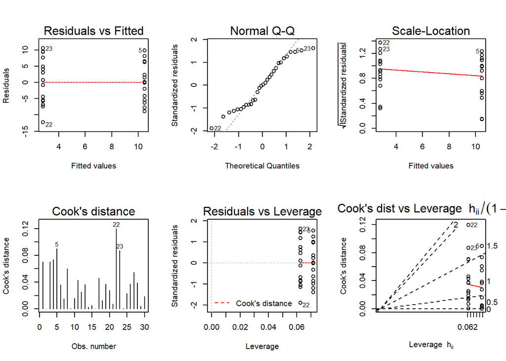

```r
write.table(as.data.frame(round(summary(m6)$coef, 4)),"clipboard",sep="\t")



# diagnostics - the qq plot is a little thin tailed,
# but I haven't found any transformations to help
par(mfrow = c(2,3))
plot(m6, which = 1:6)
```

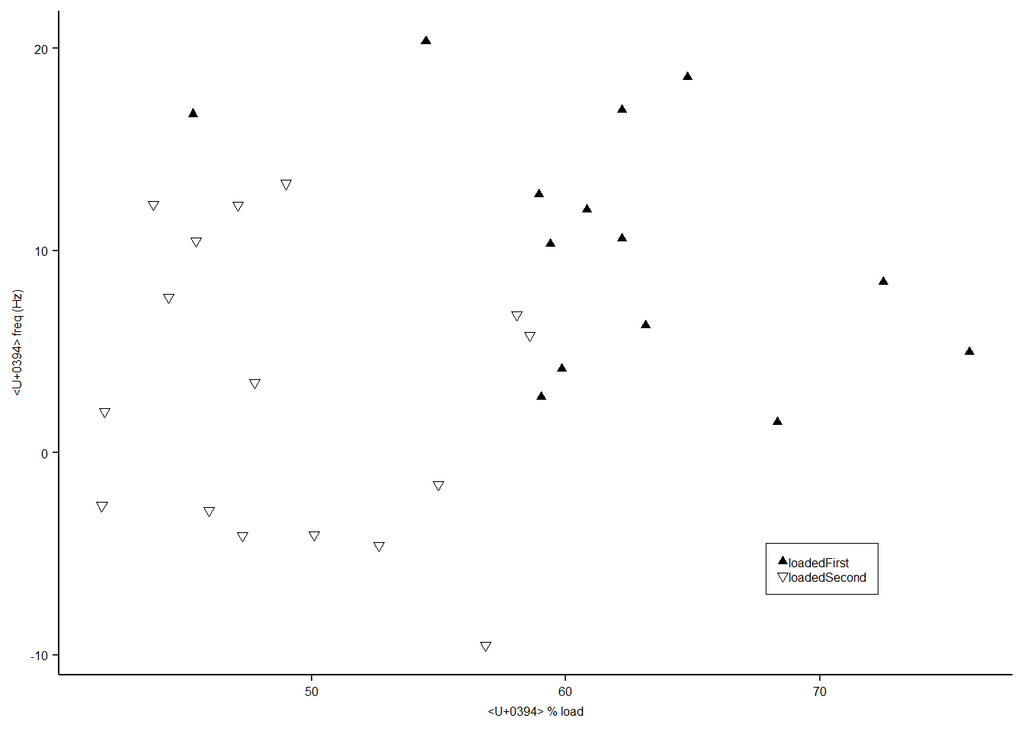

```r
par(mfrow = c(1,1))



### model visualization -- no need to use partial residuals, since
### there is only one predictor

fig4b <- ggplot(newDF, aes(x= delta_perc_load, y = delta_freq)) +
  geom_point(aes(shape = order_1)) +
  labs(x = "Δ % load", y = "Δ freq (Hz)" ) +
  # stat_smooth(method = 'lm', se = FALSE, color = "black", lty = 2, size = 0.5) +
  # scale_y_continuous(labels = scales::scientific, limits = c(-15, 25)) +
  theme(legend.title = element_blank(),
        legend.background = element_rect(colour = "black", size = 0.3),
        legend.position = c(0.8, 0.16),
        legend.text = element_text(size = 6),
        axis.text = element_text(size = 6),
        axis.title = element_text(size = 6),
        legend.key.size = unit(0.2, "cm")) +
  scale_shape_manual(values = c(17, 6))
fig4b
```

```r
# ggsave(filename = file.path(figDir, "fig4b.png"), width = 6.5/2, height = 2,
#         plot = fig4b,
#        units = "in", dpi = 500)

# calculate correlation coefficients
cor(newDF$delta_freq, newDF$delta_perc_load)**2
```

```
## [1] 0.02358109
```